# Home Credit Default Risk (HCDR)

# Phase Leader Plan

[output not shown]

# Credit Assignment Plan – Phases 1 to 4

| Task | SMART Goal | Estimated Effort (hrs) | Assigned To | Phase |
| --- | --- | --- | --- | --- |
| Define project title and description | Clearly define the project title and write a 150-word abstract using the STAR method to communicate the objective and scope | 2 | Rithvik Mysore Suresh | Phase 1 |
| Dataset selection and understanding | Review both datasets (HCDR and CaDoD), and document the structure, relevance, and reasoning for choosing one | 3 | Prajwal Venugopal | Phase 1 |
| Define baseline metrics | Identify and justify baseline metrics such as accuracy, precision, recall, F1-score, AUC, and domain-specific metrics | 2 | Venkata Gummadi | Phase 1 |
| Propose baseline and planned ML models | Choose suitable baseline models (e.g., logistic regression, decision trees) and document planned advanced models for later phases | 2 | Vijay Sunkugari | Phase 1 |
| Design baseline pipeline | Create a basic ML pipeline structure with preprocessing and baseline model training using sklearn | 3 | Vijay Sunkugari | Phase 1 |
| Draft SMART goals for Phase 1 | Write clearly defined SMART goals aligned with submission requirements | 1 | Prajwal Venugopal | Phase 1 |
| Define joins between datasets | Identify key relationships between tables (e.g., using SK_ID_CURR, SK_ID_PREV) and document join strategies | 2 | Rithvik Mysore Suresh | Phase 1 |
| Create phase leader plan table | Document project timeline and assign project manager for each phase using a clean table format | 1 | Prajwal Venugopal | Phase 1 |
| Create credit assignment plan table | Prepare this table (SMART goals, time estimation, roles) for inclusion at the top of the notebook | 1 | Rithvik Mysore Suresh | Phase 1 |
| Submit Jupyter Notebook in `.ipynb` and `.html` formats with all required content | Ensure the notebook is exported and submitted in both formats, verifying link/image visibility in incognito mode | 1 | TEAM | Phase 1 |
| Load and preprocess dataset | Download, clean, and preprocess HCDR data; handle missing values and standardize features | 3 | Venkata Gummadi | Phase 2 |
| Perform EDA | Explore and visualize key features, correlations, distributions, and identify potential outliers or data issues | 3 | Rithvik Mysore Suresh | Phase 2 |
| Implement baseline pipeline | Code and run baseline model pipeline end-to-end (train/test split, preprocessing, model, evaluation) | 4 | Vijay Sunkugari | Phase 2 |
| Conduct initial feature engineering | Engineer new features (e.g., ratios, aggregations) and test their impact on model performance | 3 | Rithvik Mysore Suresh | Phase 2 |
| Perform initial hyperparameter tuning | Use grid/random search to optimize parameters for baseline model | 3 | Prajwal Venugopal | Phase 2 |
| Prepare Phase 2 video presentation and slides | Record a 2-minute video summary and slides explaining EDA, baseline results, and feature plans | 2 | TEAM | Phase 2 |
| Second round of feature engineering | Develop new meaningful features from auxiliary tables (e.g., bureau, previous_application) | 3 | Rithvik Mysore Suresh | Phase 3 |
| Hyperparameter tuning (advanced) | Use Bayesian/advanced search methods to tune models like Random Forest, XGBoost, etc. | 3 | Venkata Gummadi | Phase 3 |
| Perform feature selection | Apply methods like mutual info, SHAP, or recursive elimination to reduce feature space | 3 | Vijay Sunkugari | Phase 3 |
| Explore ensemble methods | Combine multiple models (e.g., voting, stacking) and evaluate performance | 3 | Prajwal Venugopal | Phase 3 |
| Prepare Phase 3 video update and slides | Record a 2-minute video and create slides summarizing tuning, ensembles, and performance improvements | 2 | TEAM | Phase 3 |
| Design and implement neural network | Build and train a feedforward neural network or deep model using PyTorch or TensorFlow | 4 | Vijay Sunkugari | Phase 4 |
| Experiment with advanced architectures | Try different hidden layers, activations, optimizers, and custom loss functions | 3 | Venkata Gummadi | Phase 4 |
| Final model evaluation and comparison | Compare performance of neural network vs ensemble/baseline models using all metrics | 2 | Prajwal Venugopal | Phase 4 |
| Write final project report | Summarize problem, data, methods, results, and conclusions in a detailed report | 3 | TEAM | Phase 4 |
| Submit final video presentation, slides, and notebook | Prepare and upload final 2-minute demo, slides, and cleaned notebook to Canvas Discussion | 2 | TEAM | Phase 4 |

# Gantt Chart

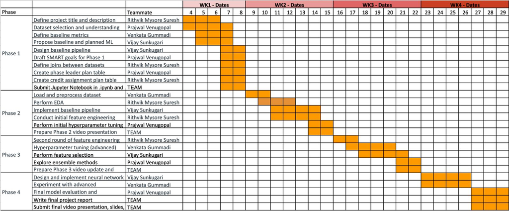

# Abstract

**Limited credit history** can prevent individuals from accessing **fair and responsible lending opportunities**. The **Home Credit Default Risk dataset** offers a **rich set of features** from multiple sources, enabling the prediction of **loan repayment potential** for such individuals. This project aims to develop a **comprehensive pipeline** that supports this goal by integrating **structured data from diverse sources** including **previous applications**, **credit bureau reports**, and **transactional histories**.

We have begun by consolidating datasets, handling **missing values**, **encoding categorical features**, and performing **exploratory analysis** to guide further processing. A **preprocessing pipeline** is under development to include **feature engineering**, **scaling**, **outlier handling**, and **dimensionality reduction**—ensuring the data is **clean**, **interpretable**, and **ready for modeling**.

Future steps include refining the pipeline with **cross-validation**, **model ensembling**, and **hyperparameter tuning**. While results are preliminary, this study is on track to deliver a **scalable** and **interpretable solution** that promotes **financial inclusion** through **responsible credit assessment**.

# Dataset: Detailed Analysis and Understanding

## Objective

The objective of this project is to predict whether a loan applicant will default on their loan. The dataset is provided by Home Credit and includes both static and behavioral data of clients from current and past loans. The main binary target is:

- `TARGET = 1`: Client defaulted on the loan
- `TARGET = 0`: Client repaid the loan

## Dataset Overview

The dataset consists of multiple interrelated tables that collectively describe:

- **Client Demographics**: such as age, gender, education level, and family status
- **Financial History**: including income, employment, and housing information
- **Credit Behavior**: repayment history, loan performance, and usage patterns
- **Loan Application Data**: current and previous applications, requested and granted credit

The **central dataset** is `application_train.csv` (and `application_test.csv` for prediction). This contains one row per client loan application and includes the main target variable.

All other datasets supplement this primary data and are connected using two key identifiers:

- `SK_ID_CURR`: Client ID – links most tables to the main application table
- `SK_ID_PREV`: Previous loan/application ID – links time-series or behavioral data from past loans

**Supporting datasets include:**

- `bureau.csv` and `bureau_balance.csv`: external credit history from other institutions
- `previous_application.csv`: previous loans requested from Home Credit
- `POS_CASH_balance.csv`: monthly status of POS/cash loans
- `installments_payments.csv`: repayment behavior of past loans
- `credit_card_balance.csv`: credit card balance and payment patterns

Together, these datasets allow for comprehensive feature engineering and modeling based on both static client characteristics and dynamic historical behavior.

### application_train.csv / application_test.csv

These are the central datasets for the project, containing information about current loan applications. Each row corresponds to a single loan application by a client. The training file (`application_train.csv`) includes the target variable (`TARGET`), while the test file does not. These datasets include demographic, employment, financial, and housing-related attributes, serving as the base for merging and feature engineering from all other supporting tables.

### bureau.csv

This file contains information about clients’ previous credits from **external financial institutions**, collected from the credit bureau. Each row represents one such past loan, and clients can have multiple records. It includes credit status (active, closed), types of loans, amounts, and durations. It is linked to the main dataset using the `SK_ID_CURR` key.

### bureau_balance.csv

This dataset provides **monthly balance information** for each credit record listed in the `bureau.csv` file. It captures the monthly credit status (e.g., paid on time, overdue, closed) and spans multiple months per loan. It helps model repayment behavior over time and links to `bureau.csv` via the `SK_ID_BUREAU` key.

### previous_application.csv

This dataset captures all **previous loan applications submitted to Home Credit** by clients, regardless of whether the application was approved or rejected. It includes information on loan types, status, requested amounts, and actual credit received. It is crucial for analyzing a client’s past interactions with Home Credit and is linked to the main dataset using `SK_ID_CURR`.

### POS_CASH_balance.csv

This table includes **monthly snapshots** of previously disbursed **Point-of-Sale (POS)** and **cash loans** issued by Home Credit. Each row corresponds to one month of a given loan’s status and remaining installments. It provides insight into payment behavior and the lifecycle of short-term credit products, and is connected via the `SK_ID_PREV` field.

### installments_payments.csv

This dataset contains **payment records** for previous Home Credit loans, showing expected versus actual payments made per installment. It includes installment numbers, payment amounts, and payment dates. It helps model repayment reliability, especially identifying missed or late payments. It is linked using `SK_ID_PREV`.

### credit_card_balance.csv

This dataset records the **monthly balance and payment activity** on Home Credit-issued credit cards. Similar to the POS data, it offers time-series records of balances, payments, and overdue days. It helps identify how responsibly a client manages their revolving credit and is connected through `SK_ID_PREV`.

### HomeCredit_columns_description.csv

This is a **metadata file** containing descriptions of all columns across the datasets. It is essential for understanding the meaning and relevance of each feature, especially when dealing with abbreviations or engineered variables.

## Summary of Relationships

| Table Name | Description | Key Join Field |
| --- | --- | --- |
| application_train/test | Main client data | SK_ID_CURR |
| bureau | Previous loans from other institutions | SK_ID_CURR |
| bureau_balance | Monthly credit data for bureau loans | SK_ID_BUREAU |
| previous_application | Past Home Credit loan applications | SK_ID_CURR |
| POS_CASH_balance | POS/cash monthly loan data | SK_ID_PREV |
| installments_payments | Installment payment history | SK_ID_PREV |
| credit_card_balance | Monthly credit card balance and usage | SK_ID_PREV |
| HomeCredit_columns_description | Metadata for all columns | N/A |

# Algorithms & Metrics:

## Machine Learning Algorithms:

Given the heterogeneity and complexity of the Home Credit Default Risk dataset—with its high dimensionality, missing values, and imbalanced classes—we plan to experiment with a variety of machine learning models before selecting the most robust one. Our baseline models will include **Logistic Regression with L1 regularization**, **Random Forests**, and **Gradient Boosting Machines (e.g., XGBoost)**, which are well-suited for handling mixed feature types and non-linear patterns. We also aim to test **Support Vector Machines (SVM)** due to their effectiveness in high-dimensional spaces, as well as **Neural Networks (MLPs)** for their flexibility in modeling complex interactions. Ultimately, model selection will be based on empirical performance and interpretability.

## Evaluation Metrics:

Given the imbalanced nature of the dataset, **ROC AUC** will be our primary evaluation metric, as it effectively captures the trade-off between sensitivity and specificity across different thresholds. We will also monitor the **F1 score**, which balances precision and recall, especially in scenarios where both false positives and false negatives carry consequences. Additional metrics include **Balanced Accuracy** (to account for class imbalance), **Precision-Recall AUC**, and the **Gini Coefficient**, a domain-specific metric commonly used in credit scoring. By comparing multiple models under these diverse metrics, we aim to ensure both predictive accuracy and practical relevance in real-world credit risk assessment.

# Description of the Pipeline Steps:

Our project will implement a robust and modular machine learning pipeline using Scikit-learn, structured as follows:

## Data Ingestion and Loading:

- Load and inspect the main application data (`application_train.csv`) and associated datasets (e.g., bureau, previous applications, credit card balance).
- Understand and visualize missing data, data types, and data distribution.

## Data Merging and Feature Consolidation

- Merge secondary datasets (e.g., `bureau.csv`, `previous_application.csv`) with the primary dataset using `SK_ID_CURR` as the key.
- Aggregate features at the customer level where needed (e.g., total number of loans, average loan amount from bureau data).

## Data Cleaning and Preprocessing

- Handle missing values:
  - Drop columns with excessive missingness.
  - Impute remaining missing values using statistical methods (mean/median or KNN imputation).
- Handle outliers (e.g., capping extreme values using quantile clipping).
- Convert categorical variables:
  - Apply one-hot encoding to nominal categorical variables.
  - Use label encoding where appropriate.

## Feature Engineering

- Create domain-specific features (e.g., credit-to-income ratio, number of previous loans).
- Generate interaction terms between key variables.
- Standardize numerical features using `StandardScaler`.

## Feature Selection

- Use mutual information, correlation analysis, or model-based feature importance to select top N features.
- Optionally, apply dimensionality reduction (e.g., PCA) for model comparison.

## Model Building

- Build a supervised classification model pipeline using `Pipeline()`:

  ```
  Pipeline([
      ('scaler', StandardScaler()),
      ('classifier', LogisticRegression())
  ])
  ```

- Try multiple algorithms (Logistic Regression, KNN, Random Forest,XGBoost) and compare performance.
- Hyperparameter tuning using `GridSearchCV`.

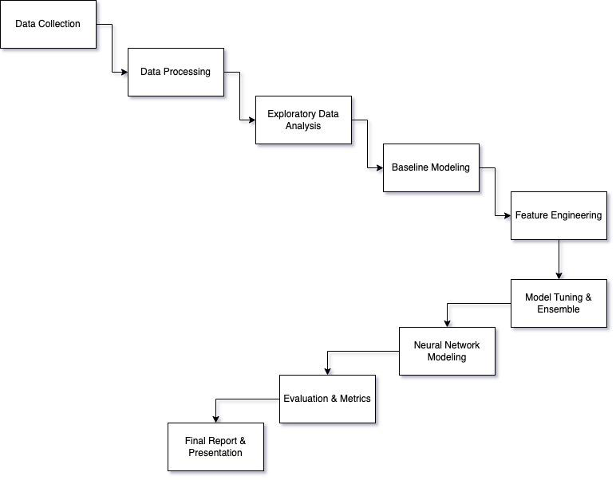

| Name | Email |
| --- | --- |
| Venkata Gummadi | vgummadi@iu.edu |
| Rithvik Mysore Suresh | rimysore@iu.edu |
| Vijay Sunkugari | visunku@iu.edu |
| Prajwal Venugopal | pvenugop@iu.edu |